# ECO634- Lab 4

Mercy Melo

# Question 1

Create four vectors of normally-distributed random numbers, norm_17, norm_30, norm_300, and norm_3000.

You should tell R that you want your random values to have a mean of 10.4 and a standard deviation of 2.4.

norm_17 should have 17 elements, norm_30 should have 30 elements, norm_300 should have 300 elements, and norm_3000 should have 3000 elements.

```r
mean <- 10.4
sd <- 2.4

norm_17 <- rnorm(n = 17, mean = mean, sd = sd)
norm_30 <- rnorm(n = 30, mean = mean, sd = sd)
norm_300 <- rnorm(n = 300, mean = mean, sd = sd)
norm_3000 <- rnorm(n = 3000, mean = mean, sd = sd)
```

# Question 2-3

Create a figure including histograms of your vectors norm_17, norm_30, norm_300, and norm_3000.

```r
require(here)
```

```r
png(filename = here("lab_04_hist_01.png"),
    width = 1500, height = 1600, res = 180,
    units = "px")
par(mfrow = c(2, 2))
hist(norm_17, main = "17 Random Points")
hist(norm_30, main = "30 Random Points")
hist(norm_300, main = "300 Random Points")
hist(norm_3000, main = "3000 Random Points")

dev.off()
```

# Question 4

# Question 5

The histograms’ shape correlates with the number of random points in each vector. When a small number of points are randomly generated, there is a larger possibility of the points not being exactly normally-distributed. This is simply due to random chance that is exacerbated by a small sample size (like flipping a coin only 3 times and getting all tails- it’s not that out of the ordinary). As the sample size increases, the dispersion of the points becomes more and more normally-distributed. Similarly, adding more points also allows the histogram to be broken down into a larger number of bins that are more specific (because there are more points within each bin).

# Question 6

Standard normal distributions are normally-distributed curves that always have a mean of 0 and a standard deviation of 1. Standard normal curves are typically used to calculate probabilities of values occurring within the range of values provided.

# Question 7 + 8

Plot a density curve for a normal distribution with mean = 10.4 and standard deviation = 2.4. Save the figure as an SVG file.

```r
mean <- 10.4
sd <- 2.4
x = seq(2, 20, length.out = 1000)
y = dnorm(x, mean = mean, sd = sd)

svg("norm_1.svg", width = 4, height = 4)

plot(x, y, main = "Normal Distribution of Mean 10.4
     \n and Standard Deviation of 2.4",
     type = "l", xlim = c(2, 20))
abline(h = 0)

dev.off()
```

# Question 9 + 10

Experiment with different sets of randomly-generated data and create a figure with 4 plots. Show code for 1 random dataset and plot.

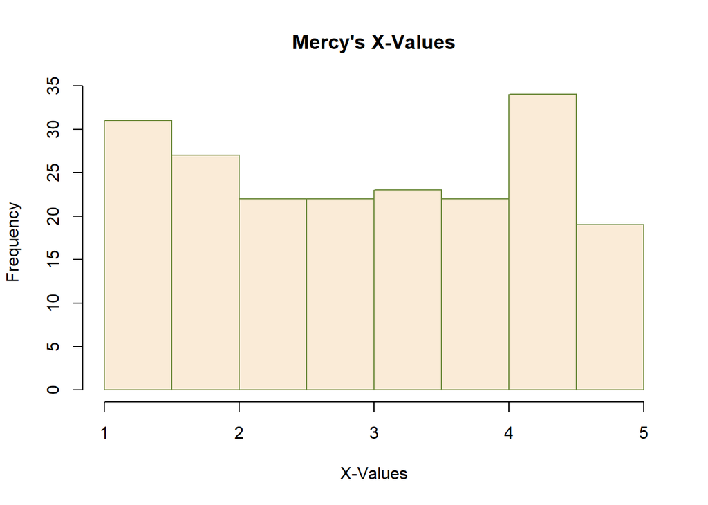

```r
n_pts = 200
x_min = 1
x_max = 5
x = runif(n = n_pts, min = x_min, max = x_max)
dat = data.frame(x = x, y_observed = rnorm(n_pts))

hist(x, main = "Mercy's X-Values", xlab = "X-Values",
     col = "antiquewhite", border = "darkolivegreen4")
```

# Question 11 + 12

```r
#Making random dataset
n_pts = 200
x_min = 1
x_max = 5
x = runif(n = n_pts, min = x_min, max = x_max)
dat = data.frame(x = x, y_observed = rnorm(n_pts))
head(dat)
```

```
##          x  y_observed
## 1 2.521939 -0.06003137
## 2 4.114911 -0.07186475
## 3 1.185726  0.23965866
## 4 1.465712 -0.93364031
## 5 4.502211 -0.83878474
## 6 4.125258  0.32705458
```

# Question 13

Use the dataset you chose for the previous question and add a column of predicted y-values and a column of residuals.

```r
#Defining line_point_slope function
line_point_slope = function(x, x1, y1, slope)
{
  get_y_intercept =
    function(x1, y1, slope)
      return(-(x1 * slope) + y1)

  linear =
    function(x, yint, slope)
      return(yint + x * slope)

  return(linear(x, get_y_intercept(x1, y1, slope), slope))
}

guess_x = 2
guess_y = 0.1
guess_slope = -0.025

y_predicted <- line_point_slope(dat$x, guess_x, guess_y, guess_slope)
pred_and_obs <- data.frame(dat, y_predicted)

resids <- pred_and_obs$y_predicted-pred_and_obs$y_observed

pred_obs_resid <- data.frame(pred_and_obs, resids)
head(pred_obs_resid)
```

```
##          x  y_observed y_predicted     resids
## 1 2.521939 -0.06003137  0.08695152  0.1469829
## 2 4.114911 -0.07186475  0.04712722  0.1189920
## 3 1.185726  0.23965866  0.12035686 -0.1193018
## 4 1.465712 -0.93364031  0.11335721  1.0469975
## 5 4.502211 -0.83878474  0.03744473  0.8762295
## 6 4.125258  0.32705458  0.04686855 -0.2801860
```

# Question 14

Create a histogram of the model’s residuals and a scatterplot of your model’s predicted values (x-axis) and residuals (y-axis).

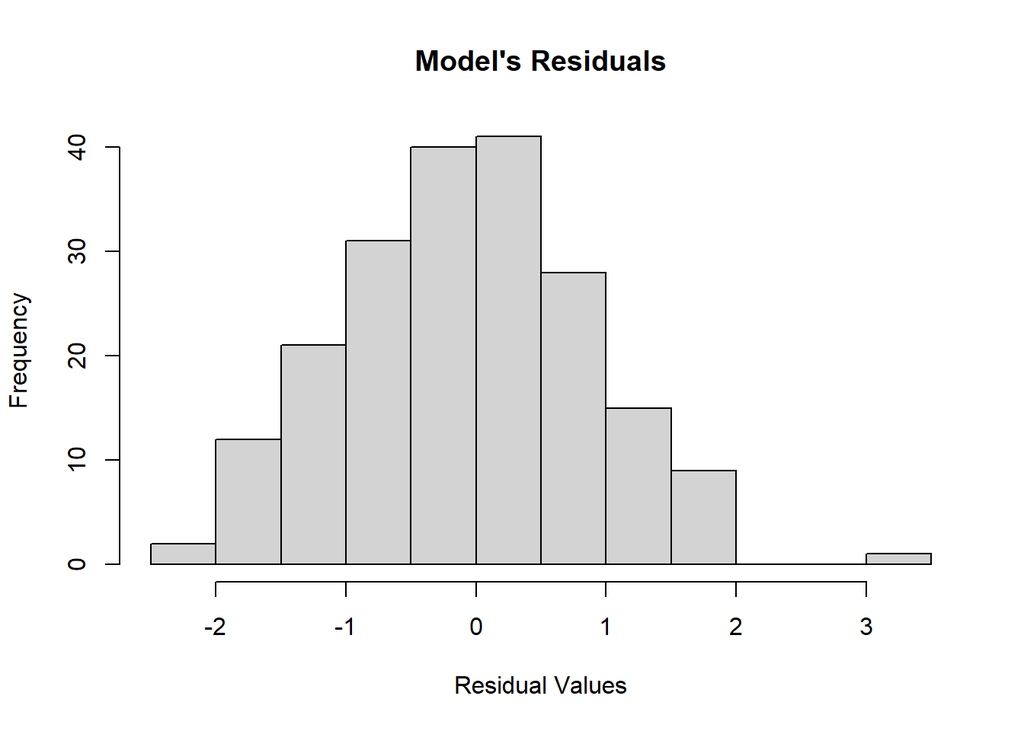

```r
hist(pred_obs_resid$resids, main = "Model's Residuals", xlab = "Residual Values")
```

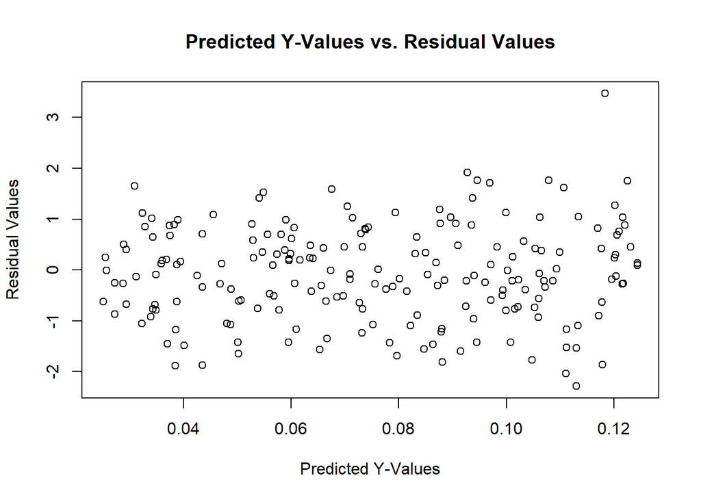

```r
plot(pred_obs_resid$y_predicted, pred_obs_resid$resids,
     xlab = "Predicted Y-Values", ylab = "Residual Values",
     main = "Predicted Y-Values vs. Residual Values")
```